# HW3

Renjie Liu

4/17/2021

## Question 1:

Load the usgdp.rda dataset and split it into a training dataset (1960 - 2012) and a test dataset (2013 - 2017)

```r
library(fpp)
library(TSA)
load('usgdp.rda')
gdp <- ts(usgdp$GDP, frequency = 1,start = 1960)

train <- window(gdp,start = 1960, end = 2012)
test <- window(gdp,start = 2013, end = 2017)
```

## Question 2:

Plot the training dataset. Is the Box-Cox transformation necessary for this data?

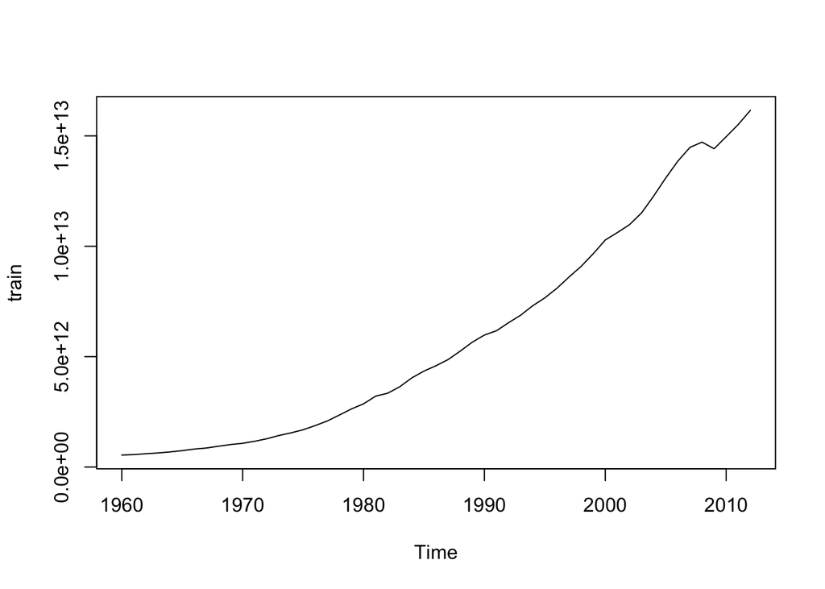

```r
plot(train)
```

```r
BoxCox.lambda(train)
```

```
## [1] 0.2310656
```

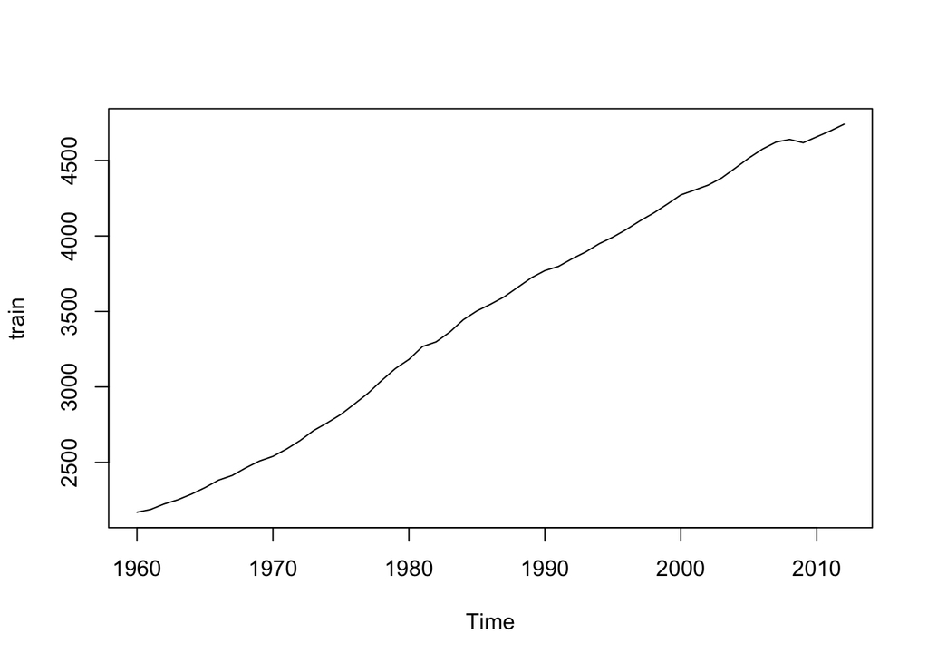

```r
train <- BoxCox(train, lambda = 0.23)
plot(train)
```

The box - cox transformation is necessary for this data because the data is increasing exponentianally. larger variance between lags as time progress.

## Question 3:

Plot the 1st and 2nd order difference of the data. Apply KPSS Test for Stationarity to determine which difference order results in a stationary dataset.

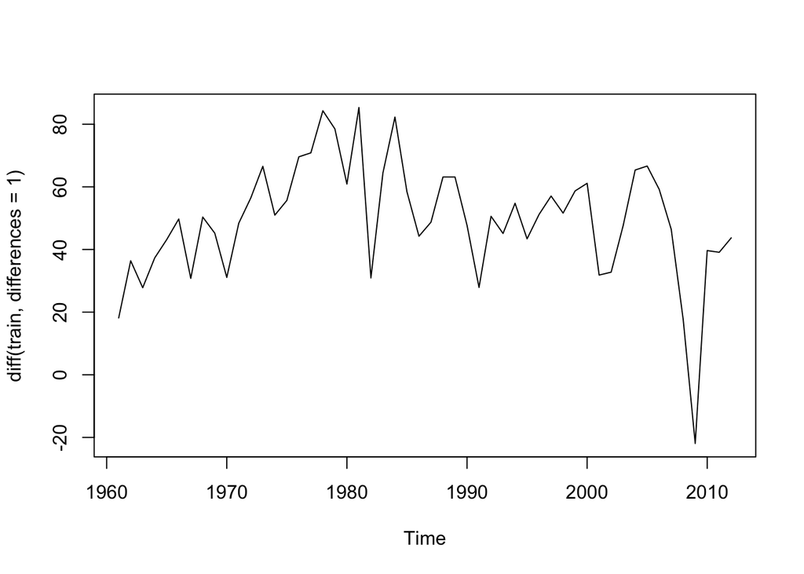

```r
library(tseries)
# first order difference of the data

plot(diff(train,differences = 1))
```

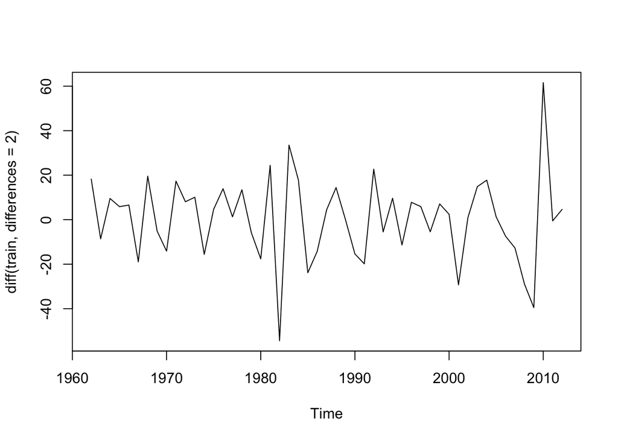

```r
# second order difference of the data
plot(diff(train,differences = 2))
```

```r
#Use kpss.test to test stationary
kpss.test(diff(train,differences = 1))
```

```
##
##  KPSS Test for Level Stationarity
##
## data:  diff(train, differences = 1)
## KPSS Level = 0.23387, Truncation lag parameter = 3, p-value = 0.1
```

```r
kpss.test(diff(train,differences = 2))
```

```
##
##  KPSS Test for Level Stationarity
##
## data:  diff(train, differences = 2)
## KPSS Level = 0.10135, Truncation lag parameter = 3, p-value = 0.1
```

Based on the kpss test. Both the first and second order difference of the data is stationary. Because the p-value is larger than 0.05, so fail to reject the null hypothesis that the time series is stationary.

## Question 4:

Fit a suitable ARIMA model to the training dataset using the auto.arima() function. Remember to transform the data first if necessary. Report the resulting 𝑝,𝑑,𝑞 and the coefficients values.

```r
auto <- auto.arima(train,seasonal = FALSE)
auto
```

```
## Series: train
## ARIMA(1,1,0) with drift
##
## Coefficients:
##          ar1    drift
##       0.4731  48.8071
## s.e.  0.1242   4.2392
##
## sigma^2 estimated as 277.9:  log likelihood=-219.19
## AIC=444.38   AICc=444.88   BIC=450.23
```

The best model from auto arima is p = 1, d = 1, and q = 0. This means that the model uses first order auto regression with first order differencing, and the model does not have moving average in the model. Drift is the intercept of the model. The Coefficients for ar1 is 0.4731

```r
eacf(train)
```

```
## AR/MA
##   0 1 2 3 4 5 6 7 8 9 10 11 12 13
## 0 x x x x x x x x x x x  x  o  o
## 1 x o o o o x o o o o o  o  o  o
## 2 o o o o o o o o o o o  o  o  o
## 3 x o o o o o o o o o o  o  o  o
## 4 x o o o o o o o o o o  o  o  o
## 5 x o o o o o o o o o o  o  o  o
## 6 x o o x o o o o o o o  o  o  o
## 7 x x o o o o o o o o o  o  o  o
```

```r
# based on the eacf, p and q can have the combination of (1,1),(1,2),(2,1)
summary(Arima(train, order=c(1,1,0), include.drift = TRUE))
```

```
## Series: train
## ARIMA(1,1,0) with drift
##
## Coefficients:
##          ar1    drift
##       0.4731  48.8071
## s.e.  0.1242   4.2392
##
## sigma^2 estimated as 277.9:  log likelihood=-219.19
## AIC=444.38   AICc=444.88   BIC=450.23
##
## Training set error measures:
##                     ME     RMSE      MAE        MPE      MAPE      MASE
## Training set 0.3825978 16.19067 12.21494 0.01159168 0.3622052 0.2429963
##                     ACF1
## Training set -0.03239236
```

```r
summary(Arima(train, order=c(1,1,1), include.drift = TRUE))
```

```
## Series: train
## ARIMA(1,1,1) with drift
##
## Coefficients:
##          ar1      ma1    drift
##       0.5258  -0.0678  48.7326
## s.e.  0.2825   0.3381   4.3997
##
## sigma^2 estimated as 283.3:  log likelihood=-219.17
## AIC=446.34   AICc=447.19   BIC=454.14
##
## Training set error measures:
##                    ME     RMSE      MAE        MPE      MAPE      MASE
## Training set 0.410535 16.18402 12.16963 0.01281247 0.3605383 0.2420949
##                     ACF1
## Training set -0.01918591
```

```r
summary(Arima(train, order=c(1,1,2),include.drift = TRUE))
```

```
## Series: train
## ARIMA(1,1,2) with drift
##
## Coefficients:
##          ar1      ma1      ma2    drift
##       0.8385  -0.3899  -0.1867  47.4635
## s.e.  0.2016   0.2500   0.1650   6.0973
##
## sigma^2 estimated as 286:  log likelihood=-218.91
## AIC=447.83   AICc=449.13   BIC=457.59
##
## Training set error measures:
##                     ME     RMSE      MAE        MPE      MAPE    MASE
## Training set 0.6959514 16.09517 12.26741 0.02660504 0.3628726 0.24404
##                     ACF1
## Training set -0.01810645
```

```r
summary(Arima(train, order=c(2,1,1),include.drift = TRUE))
```

```
## Series: train
## ARIMA(2,1,1) with drift
##
## Coefficients:
##           ar1     ar2     ma1    drift
##       -0.4829  0.4307  0.9795  48.8675
## s.e.   0.1530  0.1441  0.1077   4.1862
##
## sigma^2 estimated as 286.6:  log likelihood=-219.06
## AIC=448.12   AICc=449.43   BIC=457.88
##
## Training set error measures:
##                     ME     RMSE      MAE       MPE      MAPE      MASE
## Training set 0.3792407 16.11105 12.19013 0.0111041 0.3611918 0.2425026
##                     ACF1
## Training set -0.04464479
```

```r
# Second Order Difference
summary(Arima(train, order=c(1,2,1), include.drift = TRUE))
```

```
## Series: train
## ARIMA(1,2,1)
##
## Coefficients:
##          ar1      ma1
##       0.3129  -0.8212
## s.e.  0.1974   0.1271
##
## sigma^2 estimated as 292:  log likelihood=-216.4
## AIC=438.8   AICc=439.31   BIC=444.6
##
## Training set error measures:
##                     ME     RMSE      MAE        MPE     MAPE      MASE
## Training set 0.8570625 16.42992 12.62242 0.05753564 0.371781 0.2511025
##                    ACF1
## Training set 0.01932939
```

```r
summary(Arima(train, order=c(1,2,2),include.drift = TRUE))
```

```
## Series: train
## ARIMA(1,2,2)
##
## Coefficients:
##          ar1      ma1      ma2
##       0.0728  -0.5627  -0.1833
## s.e.  0.5551   0.5467   0.3666
##
## sigma^2 estimated as 296.6:  log likelihood=-216.28
## AIC=440.56   AICc=441.43   BIC=448.29
##
## Training set error measures:
##                     ME     RMSE      MAE        MPE      MAPE      MASE
## Training set 0.7908133 16.39081 12.54902 0.05558786 0.3696663 0.2496421
##                     ACF1
## Training set -0.00116826
```

```r
summary(Arima(train, order=c(2,2,1),include.drift = TRUE))
```

```
## Series: train
## ARIMA(2,2,1)
##
## Coefficients:
##          ar1      ar2      ma1
##       0.2786  -0.1043  -0.7648
## s.e.  0.1997   0.1657   0.1561
##
## sigma^2 estimated as 295.9:  log likelihood=-216.21
## AIC=440.43   AICc=441.3   BIC=448.15
##
## Training set error measures:
##                    ME     RMSE      MAE        MPE      MAPE      MASE
## Training set 0.720752 16.36905 12.52287 0.05360565 0.3687808 0.2491219
##                      ACF1
## Training set -0.008965165
```

Based on the AICc value. For the first order differences the ARIMA(1,1,0) model has the lowest aicc value. For the second difference the ARIMA(1,2,1) model has the lowest aicc value.

## Question 6:

Use the model chosen in Question 4 to forecast and plot the GDP forecasts with 80 and 95 % confidence levels for 2013 - 2017 (Test Period).

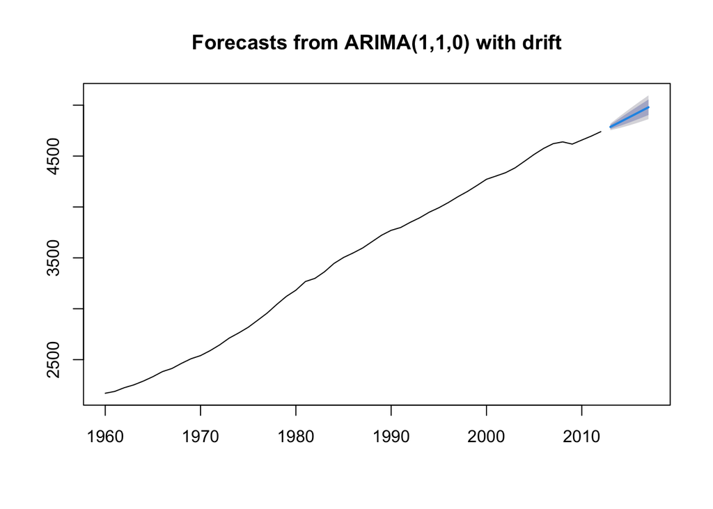

```r
# Forecase for five years so h = 5

plot(forecast(auto,h=5,level = c(80, 95)))
```

## Question 7:

Compare your forecasts with the actual values using error = actual - estimate and plot the errors. (Note: Use the forecast $mean element for the forecast estimate)

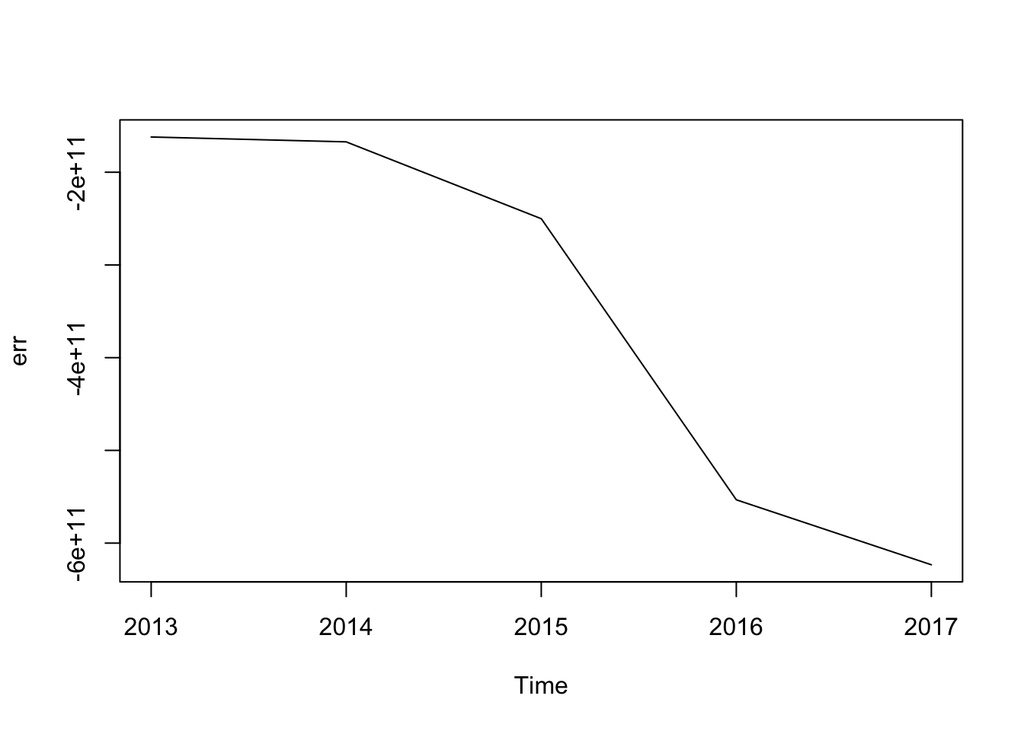

```r
fore1 <- forecast(auto,h=5,level = c(80, 95))
fore1 <- fore1$mean

# Need to use invboxcox to transform the predicted back to normal value to compare with the origional data.

fore1 <- InvBoxCox(fore1, 0.23)
actual <- usgdp[usgdp$Year>2012,]
err <- actual$GDP - fore1
plot(err)
```

```r
sum((err)^2)
```

```
## [1] 8.114318e+23
```

The sum of squared error is very big since the actual value and predictions are very big, and it gets larger after squared.